# **Panorama da inflação**

Os principais índices de inflação do Brasil, apontam em setembro de 2006 um avanço da inflação de em média **0.22%**. Com esse resultado, no ano a inflação acumula uma variação média positiva de **1.55%**, e em 12 meses uma variação média acumulada de **3.28%**.

[output not shown]

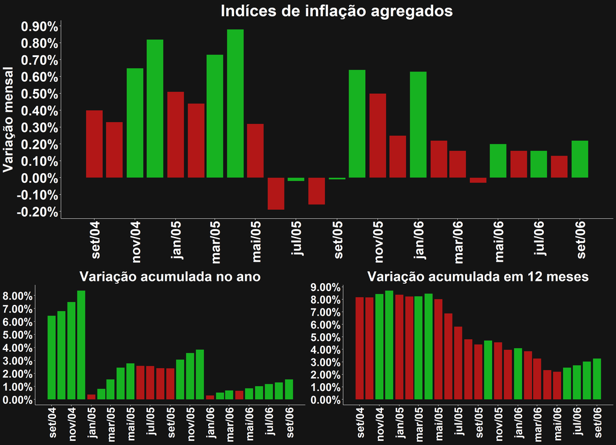

Índices selecionados para a média: IPCA, INPC e IGP-M.

# IPCA

|  | 09/2005 | 08/2006 | 09/2006 |
| --- | --- | --- | --- |
| Variação mensal | 0.35% | 0.05% | 0.21% |
| Variação acumulada no ano | 3.95% | 1.78% | 2% |
| Variação acumulada em 12 meses | 6.04% | 3.84% | 3.7% |

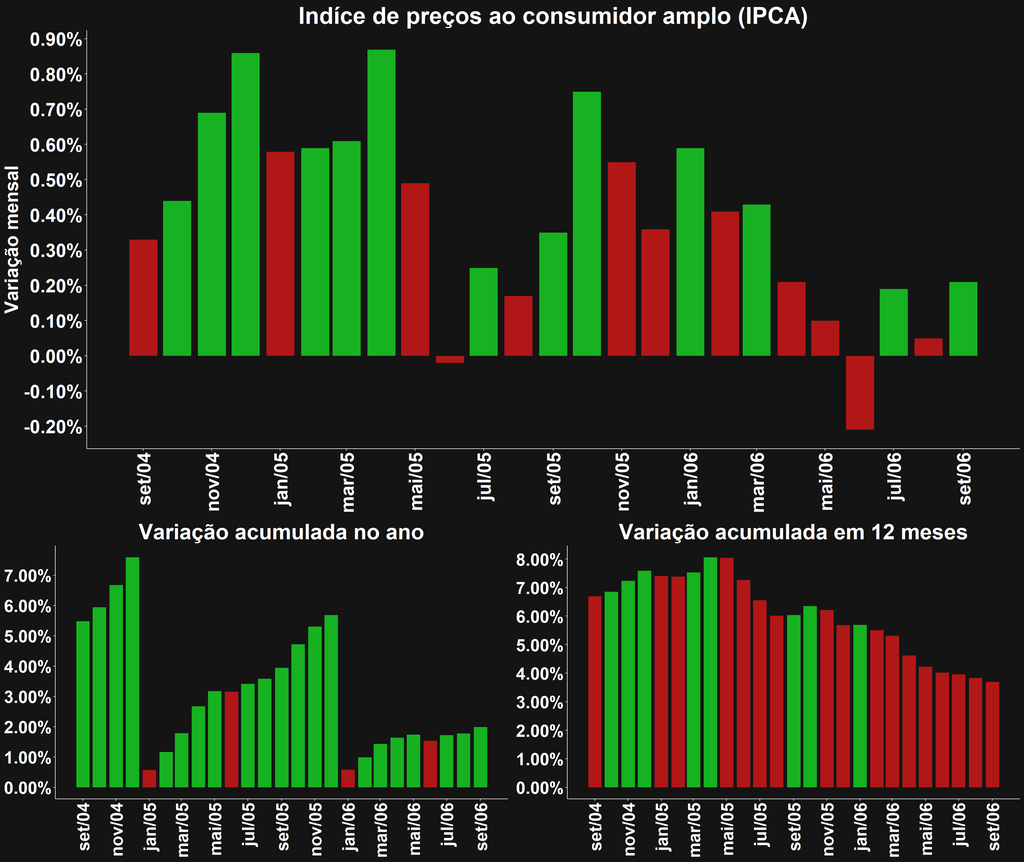

Os grupos que tiveram maior resultado positivo foram Despesas pessoais (0.89%) e Vestuário (0.46%), e negativo Artigos de residência (-0.14%) e Comunicação (-0.07%).

|  | Variação mensal | Variação acumulada no ano | Peso mensal |
| --- | --- | --- | --- |
| Alimentação e bebidas | 0.08% | -1.08% | 20.27% |
| Habitação | 0.42% | 2.75% | 13.69% |
| Artigos de residência | -0.14% | -2.14% | 4.82% |
| Vestuário | 0.46% | 2.7% | 6.5% |
| Transportes | -0.01% | 2.08% | 20.92% |
| Saúde e cuidados pessoais | 0.28% | 5.13% | 10.79% |
| Despesas pessoais | 0.89% | 5.14% | 9.39% |
| Educação | -0.01% | 5.84% | 7.11% |
| Comunicação | -0.07% | -0.12% | 6.52% |

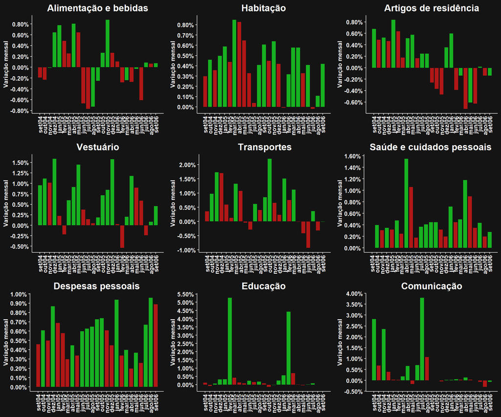

A nível de sub-itens os que mais influenciaram positivamente no resultado em relação ao seu peso foram Empregado doméstico (1.97%%) e Taxa de água e esgoto (1.89%%), e negativamente Mamão (-21.73%%) e Etanol (-3.76%%).

|  | Variação mensal | Variação acumulada no ano | Peso mensal |
| --- | --- | --- | --- |
| Frango inteiro | 5.27% | 1.29% | 0.48% |
| Empregado doméstico | 1.97% | 5.5% | 2.86% |
| Taxa de água e esgoto | 1.89% | 2.69% | 1.59% |
| Plano de saúde | 0.77% | 2.34% | 3.21% |

|  | Variação mensal | Variação acumulada no ano | Peso mensal |
| --- | --- | --- | --- |
| Cebola | -13.92% | -33.12% | 0.07% |
| Mamão | -21.73% | 50.67% | 0.13% |
| Etanol | -3.76% | -3.54% | 0.42% |
| Açúcar cristal | -5.93% | -6.45% | 0.23% |

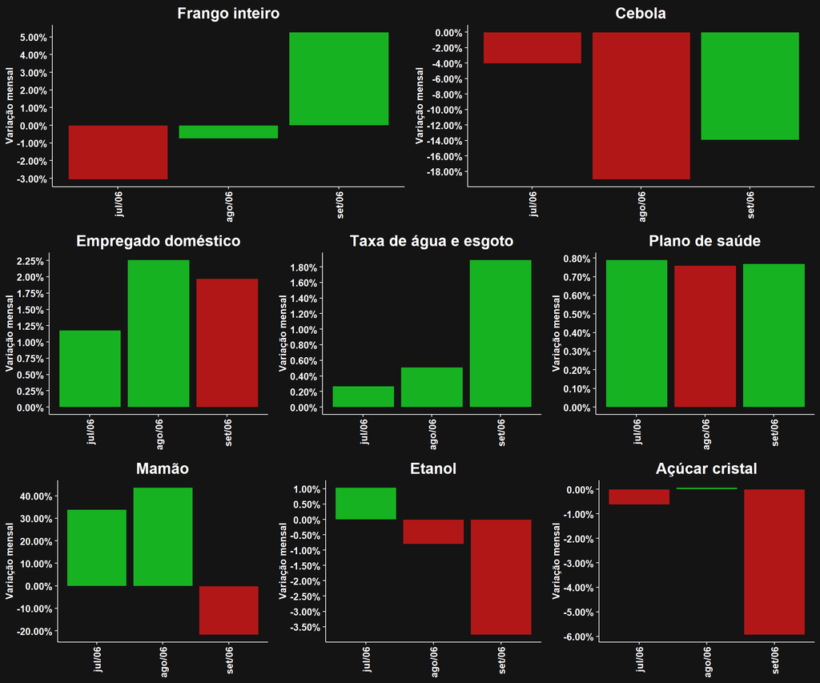

# INPC

O Indíce Nacional de Preços ao Consumidor (INPC) variou 0.16% em setembro, valor superior ao mesmo período do ano anterior quando apresentou uma taxa de 0.15%. Com esse resultado o indíce acumula no ano uma variação positiva de 1.32%, e em 12 meses uma variação positiva de 2.86%.

|  | 09/2005 | 08/2006 | 09/2006 |
| --- | --- | --- | --- |
| Variação mensal | 0.15% | -0.02% | 0.16% |
| Variação acumulada no ano | 3.47% | 1.16% | 1.32% |
| Variação acumulada em 12 meses | 4.99% | 2.85% | 2.86% |

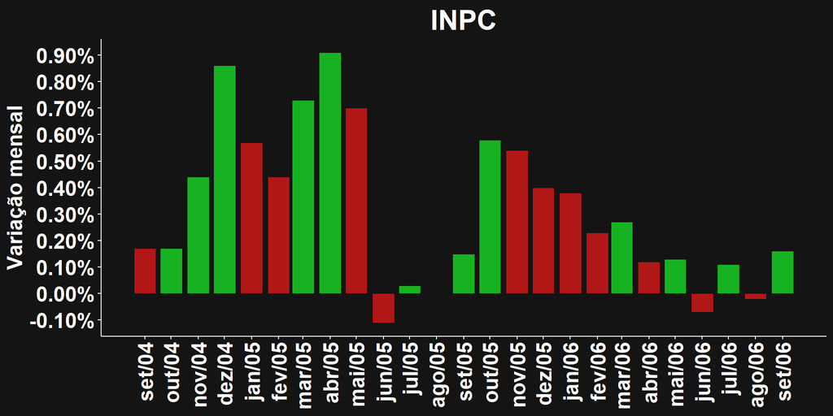

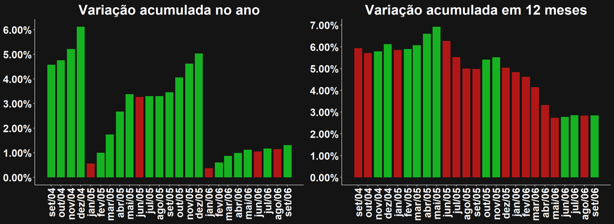

# IGP-M

O Indíce Geral de Preços de Mercado (IGP-M) variou 0.29% em setembro, valor superior ao mesmo período do ano anterior quando apresentou uma taxa de -0.53%. Com esse resultado o indíce acumula no ano uma variação positiva de 1.32%, e em 12 meses uma variação positiva de 3.28%.

|  | 09/2005 | 08/2006 | 09/2006 |
| --- | --- | --- | --- |
| Variação mensal | -0.53% | 0.37% | 0.29% |
| Variação acumulada no ano | -0.18% | 1.03% | 1.32% |
| Variação acumulada em 12 meses | 2.17% | 2.43% | 3.28% |

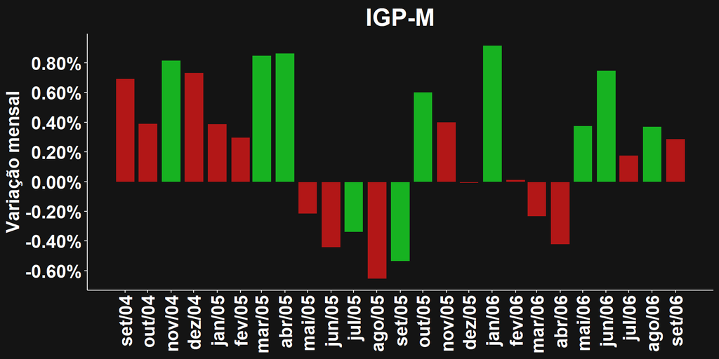

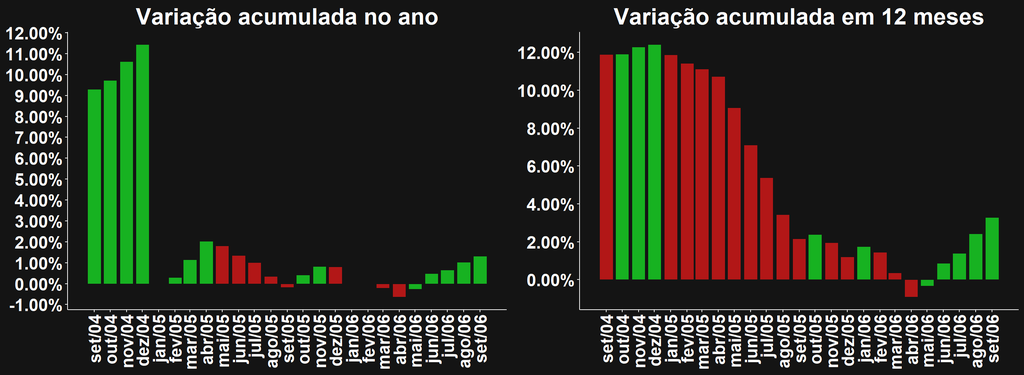

# IGP-DI

O Indíce Geral de Preços - Disponibilidade Interna (IGP-DI) variou 0.24% em setembro, valor superior ao mesmo período do ano anterior quando apresentou uma taxa de -0.13%. Com esse resultado o indíce acumula no ano uma variação positiva de 1.38%, e em 12 meses uma variação positiva de 3.16%.

|  | 09/2005 | 08/2006 | 09/2006 |
| --- | --- | --- | --- |
| Variação mensal | -0.13% | 0.41% | 0.24% |
| Variação acumulada no ano | -0.14% | 1.14% | 1.38% |
| Variação acumulada em 12 meses | 2.08% | 2.78% | 3.16% |

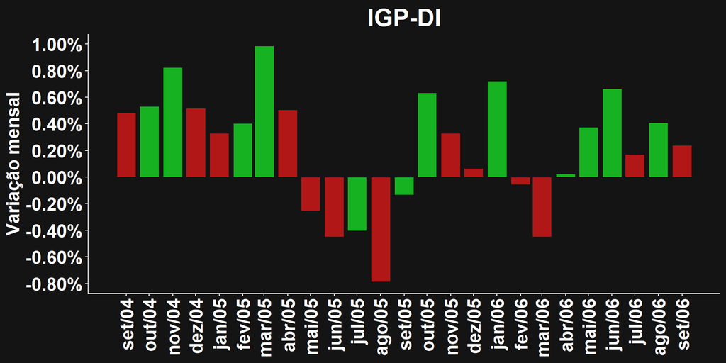

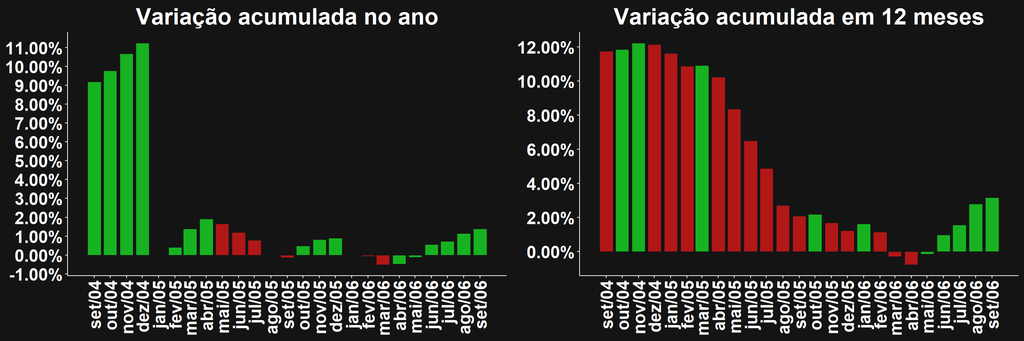

[output not shown]

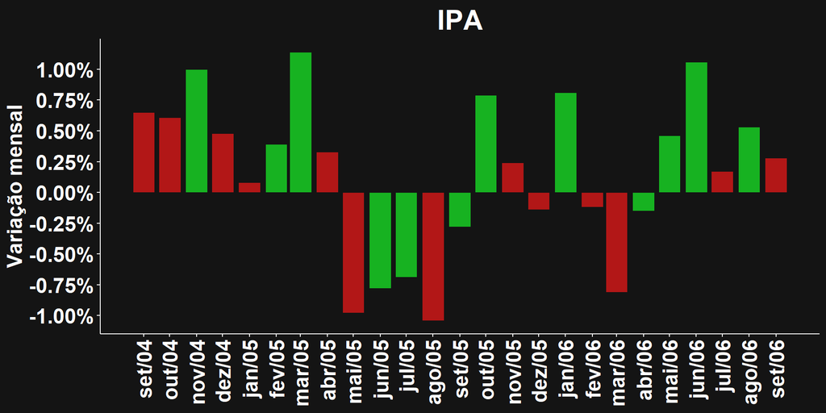

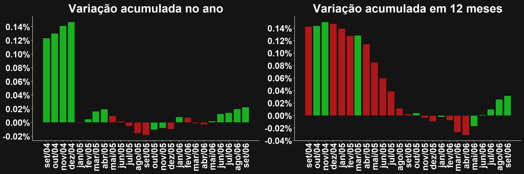

O Indíce de Preços ao Consumidor (IPC), integrante do IGP-DI com peso de 30%, apresentou variação de 0.19% em setembro, valor superior ao mesmo período do ano anterior quando apresentou uma taxa de 0.09%. Com esse resultado o indíce acumula no ano uma variação positiva de 0.38%, e em 12 meses uma variação positiva de 2.51%.

|  | 09/2005 | 08/2006 | 09/2006 |
| --- | --- | --- | --- |
| Variação mensal | 0.09% | 0.16% | 0.19% |
| Variação acumulada no ano | 2.56% | 0.19% | 0.38% |
| Variação acumulada em 12 meses | 4.57% | 2.4% | 2.51% |

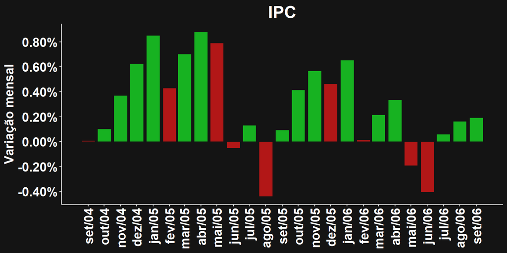

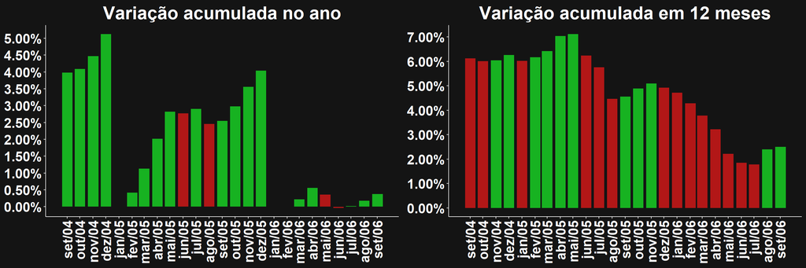

|  | 09/2005 | 08/2006 | 09/2006 |
| --- | --- | --- | --- |
| Variação mensal | 0.24% | 0.24% | 0.11% |
| Variação acumulada no ano | 5.15% | 3.73% | 3.85% |
| Variação acumulada em 12 meses | 8.52% | 5.23% | 5.09% |

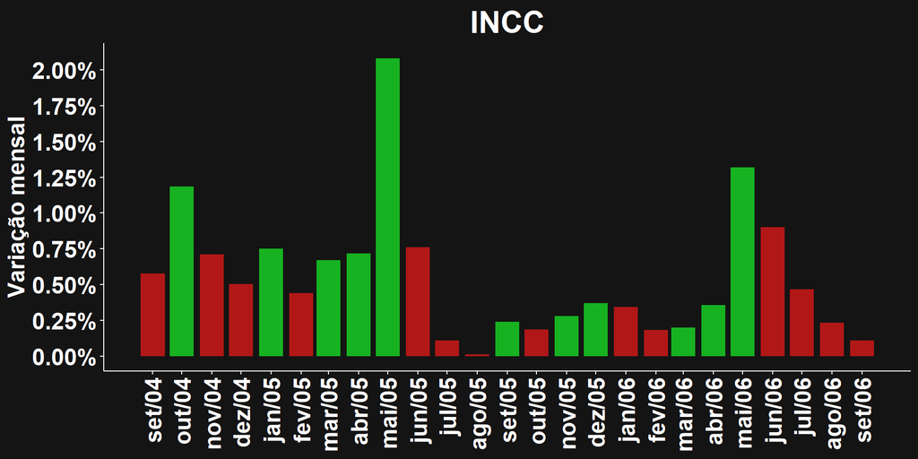

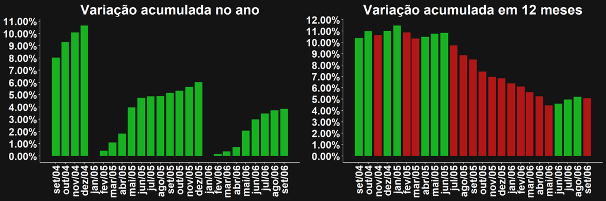

# Estatísticas

As estatísticas descritivas a seguir são feitas com base nos últimos 48 meses, e tem como objetivo possibilitar a avaliação do resultado observado em comparação aos períodos anteriores.

|  | Minimo | 1 Quartil | Mediana | Media | 3 Quartil | Maximo | Desvio Padrão |
| --- | --- | --- | --- | --- | --- | --- | --- |
| IPCA | -0.21% | 0.32% | 0.52% | 0.63% | 0.75% | 3.02% | 0.6% |
| INPC | -0.11% | 0.17% | 0.42% | 0.62% | 0.75% | 3.39% | 0.72% |
| IGP-M | -1% | 0.14% | 0.61% | 0.76% | 1.15% | 5.19% | 1.16% |
| IGP-DI | -0.79% | 0.14% | 0.51% | 0.73% | 1.06% | 5.84% | 1.17% |
| IPA | -1.68% | 0.02% | 0.57% | 0.79% | 1.3% | 7.45% | 1.58% |
| IPC | -0.44% | 0.16% | 0.43% | 0.56% | 0.78% | 3.14% | 0.65% |
| INCC | 0.02% | 0.34% | 0.72% | 0.84% | 1.14% | 2.84% | 0.63% |

Levando em consideração o desvio padrão de cada indíce, proporcionalmente os que mais se afastaram da média foram o INCC, o IPCA e o INPC.

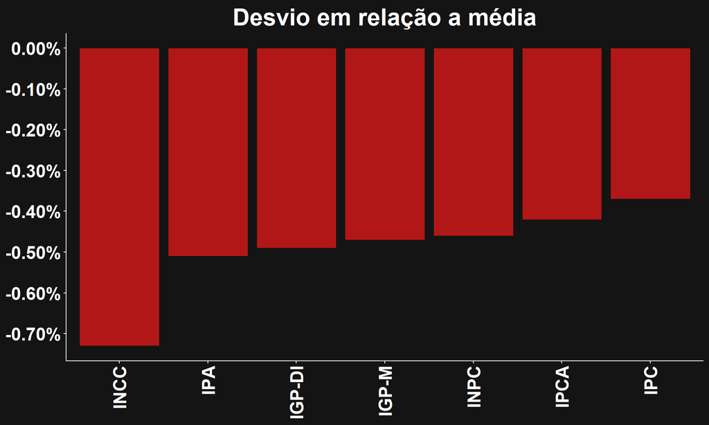

**João Victor Gomes**  
**jvg.santana@gmail.com**  
**[linkedin.com/in/jvictorgomes](https://www.linkedin.com/in/jvictorgomes/)**